# task 4

Nzambuli Daniel

2024-07-14

# Question 1: Factorial Arrangement

Consider a factorial experiment with the following factors and levels:

- Factor A: Temperature (2 levels: Low and High) - **Fixed Effect**
- Factor B: Humidity (2 levels: Low and High) - **Fixed Effect**
- Factor C: Light Exposure (2 levels: Low and High) - **Fixed Effect**

# a. How many treatment combinations are there in this factorial experiment?

Taking that the levels of each factor are mutually exclusive. That is if

- temperature is low if and only if temperature is not high
- and it is the same for humidity and light exposure

```r
library(ggplot2)
# both events at the same time
treat_comb = combinat::combn(c("A1","A2", "B1", "B2", "C1", "C2"), 3)
treat_comb
```

```
##      [,1] [,2] [,3] [,4] [,5] [,6] [,7] [,8] [,9] [,10] [,11] [,12] [,13] [,14]
## [1,] "A1" "A1" "A1" "A1" "A1" "A1" "A1" "A1" "A1" "A1"  "A2"  "A2"  "A2"  "A2"
## [2,] "A2" "A2" "A2" "A2" "B1" "B1" "B1" "B2" "B2" "C1"  "B1"  "B1"  "B1"  "B2"
## [3,] "B1" "B2" "C1" "C2" "B2" "C1" "C2" "C1" "C2" "C2"  "B2"  "C1"  "C2"  "C1"
##      [,15] [,16] [,17] [,18] [,19] [,20]
## [1,] "A2"  "A2"  "B1"  "B1"  "B1"  "B2"
## [2,] "B2"  "C1"  "B2"  "B2"  "C1"  "C1"
## [3,] "C2"  "C2"  "C1"  "C2"  "C2"  "C2"
```

remove all the columns where the initial statement is not collaborated

### Validate selection

```r
check_combn = function(comb){
  if ("A1" %in% comb && "A2" %in% comb)
    return(FALSE)
  if ("B1" %in% comb && "B2" %in% comb)
    return(FALSE)
  if ("C1" %in% comb && "C2" %in% comb)
    return(FALSE)
  return(T)
}
```

```r
treat_comb = treat_comb[, apply(treat_comb, 2, check_combn)]
treat_comb
```

```
##      [,1] [,2] [,3] [,4] [,5] [,6] [,7] [,8]
## [1,] "A1" "A1" "A1" "A1" "A2" "A2" "A2" "A2"
## [2,] "B1" "B1" "B2" "B2" "B1" "B1" "B2" "B2"
## [3,] "C1" "C2" "C1" "C2" "C1" "C2" "C1" "C2"
```

### Answer

> there are `8 treatment combinations` based on the information given

# b. Write down the full factorial design matrix including all treatment combinations.

```r
library(dplyr)
library(stringr)
full_design = data.frame(t(treat_comb))
colnames(full_design) = c("Temperature_A", "Humidity_B", "Light_Exposure_C")

full_design = full_design %>% mutate(
  across(everything(), ~case_when(
    endsWith(., "1")~ "low",
    endsWith(., "2")~ "high",
    TRUE ~ .
  ))
)

full_design
```

```
##   Temperature_A Humidity_B Light_Exposure_C
## 1           low        low              low
## 2           low        low             high
## 3           low       high              low
## 4           low       high             high
## 5          high        low              low
## 6          high        low             high
## 7          high       high              low
## 8          high       high             high
```

# c. Assume you have conducted the experiment and collected data on the response variable.

Experiments that are impacted by the three observed factors

> 1. **Plant Growth Studies**: The growth and health of plants are highly dependent on light, temperature, and humidity(Aggie Horticulture, 2019).
> 2. **Evaporation Experiments**: Experiments investigating the rate of evaporation of liquids often need to control for temperature, humidity, and light exposure(Awana, 2013).
> 3. **Material Degradation**: Studies on the degradation of materials, such as hair or textiles, often consider the effects of temperature, humidity, and light(Kenji Kuwayama et al., 2023).
> 4. **Sleep Quality Research**: Research on sleep quality sometimes examines the effects of environmental conditions like temperature, humidity, and light exposure(Cao et al., 2020).
> 5. **Greenhouse Management**: In greenhouse settings, the interplay between light, temperature, and humidity is crucial for optimizing plant growth(tempCube, 2023).

Choosing to generate a random count of desloratadine in pg/mg in hair from the material degradation experiment

## Perform a factorial ANOVA to analyze the effects of Factors A, B, and C on the response.

Taking that there is an equal chance of finding desloratadine in hair data is generated using a uniform distribution.

```r
temperature_effect <- c("low(T)" = -30, "high(T)" = 60)
humidity_effect <- c("low(H)" = 18, "high(H)" = 90)
light_exposure_effect <- c("low(L)" = 254 , "high(L)" = 365)
```

```r
set.seed(221)
response_2 = runif(64, min = 150, max = 300)

response = response_2
response
```

```
##  [1] 240.8237 150.7125 240.6621 240.0381 191.3877 183.7842 165.9399 208.2825
##  [9] 235.6286 183.3221 230.9930 268.9603 180.7917 225.3240 236.9588 267.2433
## [17] 167.2134 173.6662 234.7724 251.1485 186.6803 273.2655 185.1105 273.9806
## [25] 283.4890 274.6883 229.0531 252.9634 264.9648 237.3170 220.4712 293.0092
## [33] 189.7797 166.8338 185.7946 225.5555 180.7080 278.4912 212.2327 173.9172
## [41] 293.2917 230.6697 263.8832 269.9585 289.1868 285.2350 222.5930 245.8500
## [49] 189.1166 198.7447 280.5727 244.7192 270.8006 176.8477 221.6155 181.0067
## [57] 225.9548 156.9907 240.0029 192.7213 159.6752 179.0178 264.5481 254.0306
```

```r
des_data = data.frame (
  Temperature = rep(rep(c("low(T)", "high(T)"), each = 4), 8),
  Humidity = rep(rep(c("low(H)", "high(H)"), times = 4), 8),
  Light_exposure = rep(rep(c("low(L)", "high(L)"), times = 2, each = 2), 8),
  Treatment = rep(as.factor(seq(1,8)), 8),
  Replicates = as.factor(rep(seq(1, 8), each = 8)),
  Response = response
)

des_data$Response = with(des_data, Response +
                          temperature_effect[Temperature] +
                          humidity_effect[Humidity] +
                          light_exposure_effect[Light_exposure])

des_data = des_data %>%
  mutate(Temperature = as.factor(Temperature)) %>%
  mutate(Humidity = as.factor(Humidity)) %>%
  mutate(Light_exposure = as.factor(Light_exposure))

head(des_data)
```

```
##   Temperature Humidity Light_exposure Treatment Replicates Response
## 1      low(T)   low(H)         low(L)         1          1 482.8237
## 2      low(T)  high(H)         low(L)         2          1 464.7125
## 3      low(T)   low(H)        high(L)         3          1 593.6621
## 4      low(T)  high(H)        high(L)         4          1 665.0381
## 5     high(T)   low(H)         low(L)         5          1 523.3877
## 6     high(T)  high(H)         low(L)         6          1 587.7842
```

#### Confirm correct replication

```r
table(des_data$Humidity, des_data$Light_exposure, des_data$Replicate)
```

```
## , ,  = 1
##
##
##           high(L) low(L)
##   high(H)       2      2
##   low(H)        2      2
##
## , ,  = 2
##
##
##           high(L) low(L)
##   high(H)       2      2
##   low(H)        2      2
##
## , ,  = 3
##
##
##           high(L) low(L)
##   high(H)       2      2
##   low(H)        2      2
##
## , ,  = 4
##
##
##           high(L) low(L)
##   high(H)       2      2
##   low(H)        2      2
##
## , ,  = 5
##
##
##           high(L) low(L)
##   high(H)       2      2
##   low(H)        2      2
##
## , ,  = 6
##
##
##           high(L) low(L)
##   high(H)       2      2
##   low(H)        2      2
##
## , ,  = 7
##
##
##           high(L) low(L)
##   high(H)       2      2
##   low(H)        2      2
##
## , ,  = 8
##
##
##           high(L) low(L)
##   high(H)       2      2
##   low(H)        2      2
```

## Provide the ANOVA table summarizing the results.

```r
anova_table = aov(Response~Temperature*Humidity*Light_exposure, data = des_data)

summary(anova_table)
```

```
##                                     Df Sum Sq Mean Sq F value   Pr(>F)
## Temperature                          1 127587  127587  80.066 2.19e-12 ***
## Humidity                             1  85381   85381  53.580 1.02e-09 ***
## Light_exposure                       1 263449  263449 165.325  < 2e-16 ***
## Temperature:Humidity                 1   4427    4427   2.778    0.101
## Temperature:Light_exposure           1   2856    2856   1.792    0.186
## Humidity:Light_exposure              1   2289    2289   1.437    0.236
## Temperature:Humidity:Light_exposure  1   1201    1201   0.754    0.389
## Residuals                           56  89238    1594
## ---
## Signif. codes:  0 '***' 0.001 '**' 0.01 '*' 0.05 '.' 0.1 ' ' 1
```

## Interpret the p-values and determine which factors (if any) have statistically significant effects on the response variable.

> **Observation**

> $H_0$ there is no statistically significant difference in the mean concentration of desloratadine in decomposing hair

> $H_1$ there is at-least one mean that is statistically and significant different from the other mean concentration of desloratadine in decomposing hair
> - **Temperature**, **humidity** and **light exposure** have p-values that are less than the significant value of `0.05`
> - the cross interactions **Temperature:humidity** , **Temperature:light exposure, Humidity:light exposure** and **Temperature:Humidity:light exposure** have a $p-value\gt0.05$

> **Interpretation**
> - **Temperature**, **humidity** and **light exposure** have a great impact on the concentration of desloratadine in decomposing hair
> - Their interaction however has no significant difference in the observed mean of desloratadine in decomposing hair

> **Conclusion**

> There needs to be a post-hoc to understand the what specific combination of factors cause this difference for Temperature, Humidity and Light Exposure

### Post-hoc Analysis

```r
library(agricolae)

temp_lsd = LSD.test(anova_table, c("Humidity", "Temperature", "Light_exposure"))$groups
temp_lsd
```

```
##                         Response groups
## high(H):high(T):high(L) 752.1650      a
## high(H):low(T):high(L)  668.2581      b
## low(H):high(T):high(L)  659.1837      b
## high(H):high(T):low(L)  633.9103      b
## low(H):low(T):high(L)   591.2168      c
## low(H):high(T):low(L)   547.5244      d
## high(H):low(T):low(L)   505.9535      e
## low(H):low(T):low(L)    470.1622      e
```

> **Observations**

> There are `5 groups`
> 1. **Group 1**
>    - high(H):high(T):high(L)
> 2. **Group 2**
>    - high(H):low(T):high(L)
>    - low(H):high(T):high(L)
>    - high(H):high(T):low(L)
> 3. **Group 3**
>    - low(H):low(T):high(L)
> 4. **Group 4**
>    - low(H):high(T):low(L)
> 5. **Group 5**
>    - high(H):low(T):low(L)
>    - low(H):low(T):low(L)

> The highest concentration is found when there is `high humidity` , `high temperature` and `high light exposure`

> The lowest concentration is found when there is `low humidity` , `low temperature` and `low light intensity`

> **Conclusion**

> Desloratadine is an antihistamine used to relieve allergy symptoms such as watery eyes, runny nose; Additionally, desloratadine is used to treat skin hives and itching in people with chronic skin reactions(Drugscom,2019). The enzyme seems to be very sensitive to low temperatures, low humidity and low light intensity.

### Interaction plot

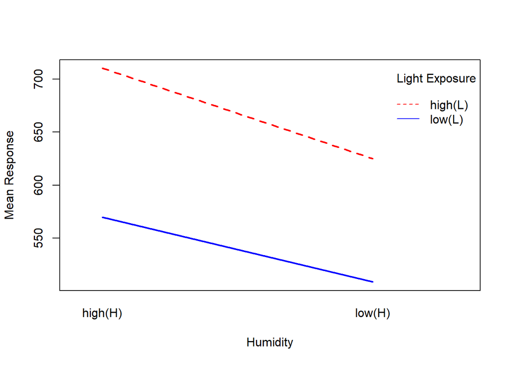

```r
interaction.plot(
  des_data$Humidity, des_data$Light_exposure, des_data$Response,
  xlab = "Humidity", ylab = "Mean Response", trace.label = "Light Exposure",
  col = c("red", "blue"), lwd = 2
)
```

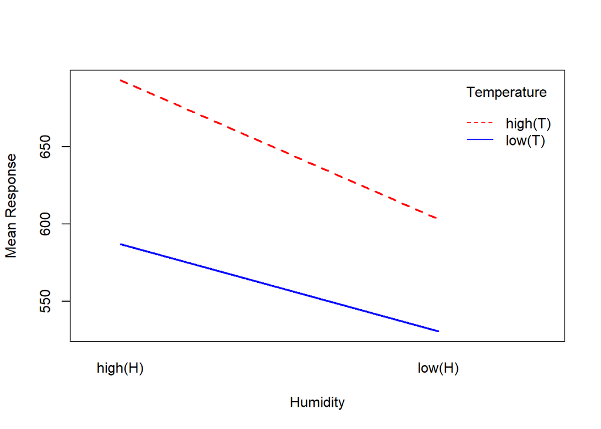

```r
interaction.plot(
  des_data$Humidity, des_data$Temperature, des_data$Response,
  xlab = "Humidity", ylab = "Mean Response", trace.label = "Temperature",
  col = c("red", "blue"), lwd = 2
)
```

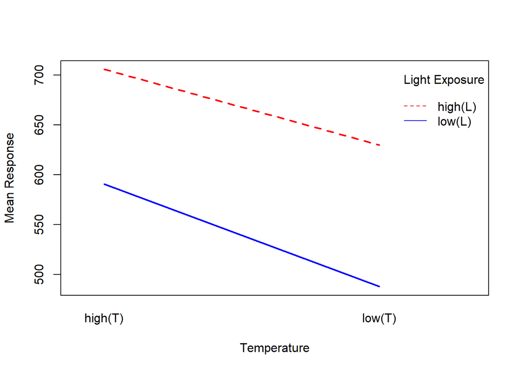

```r
interaction.plot(
  des_data$Temperature, des_data$Light_exposure, des_data$Response,
  xlab = "Temperature", ylab = "Mean Response", trace.label = "Light Exposure",
  col = c("red", "blue"), lwd = 2
)
```

> **Observation**

> there is no cross interaction between the variables however:
> - There is a **convergence** in the case of `` Humidity``moves from high to low``and Light Exposure `` , `` Humidity``moves from high to low``and Temperature ``
> - There is **divergence** in the case of `Temperature moves from high to low and Light Exposure`

> a graphical analysis to understand the distribution better.

### Box plots

```r
data_1 = des_data[, c(1, 2, 3, 6)]
data_1$interactions = interaction(data_1$Humidity, data_1$Light_exposure, data_1$Temperature)
head(data_1)
```

```
##   Temperature Humidity Light_exposure Response           interactions
## 1      low(T)   low(H)         low(L) 482.8237   low(H).low(L).low(T)
## 2      low(T)  high(H)         low(L) 464.7125  high(H).low(L).low(T)
## 3      low(T)   low(H)        high(L) 593.6621  low(H).high(L).low(T)
## 4      low(T)  high(H)        high(L) 665.0381 high(H).high(L).low(T)
## 5     high(T)   low(H)         low(L) 523.3877  low(H).low(L).high(T)
## 6     high(T)  high(H)         low(L) 587.7842 high(H).low(L).high(T)
```

```r
fill_light = ggplot(data_1, aes(x=interactions, y=Response, fill=Light_exposure)) +
  geom_boxplot() +
  theme_minimal() +
  labs(title="Boxplot of Response by Interactions", x="Light_exposure", y="Response")+
  theme(axis.text.x = element_text(angle = 45, hjust = 1))

fill_temp = ggplot(data_1, aes(x=interactions, y=Response, fill=Temperature)) +
  geom_boxplot() +
  theme_minimal() +
  labs(title="Boxplot of Response by Interactions", x="Temperature", y="Response")+
  theme(axis.text.x = element_text(angle = 45, hjust = 1))

fill_humidity = ggplot(data_1, aes(x=interactions, y=Response, fill=Humidity)) +
  geom_boxplot() +
  theme_minimal() +
  labs(title="Boxplot of Response by Interactions", x="Humidity", y="Response")+
  theme(axis.text.x = element_text(angle = 45, hjust = 1))
```

```r
library(gridExtra)
```

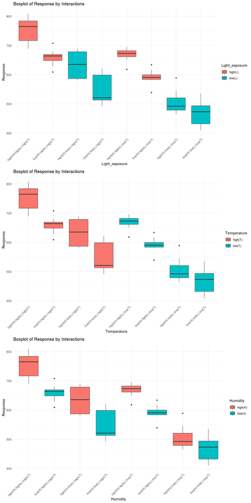

```r
grid.arrange(fill_light, fill_temp, fill_humidity, nrow = 3, ncol = 1)
```

# Question 2: Split-Plot Arrangement

Consider a split-plot experiment where the main plots (whole plots) receive different treatments and subplots (split-plots) within each main plot receive additional treatments. The experiment has:

- Main Plot Factor: Fertilizer Type (2 levels: Organic and Inorganic) - **Fixed Effect**
- Subplot Factor: Irrigation Frequency (3 levels: Low, Medium, High) - **Random Effect**

> **Note**

> In a split-plot design, larger plots (whole plots) are assigned to the main treatments, which are easier or more economical to change. Subplots within these whole plots receive the secondary treatments, which are typically more detailed and require finer control (Zach, 2020).

# a. Describe how the split-plot arrangement is structured in terms of whole plots and split-plots.

**Whole Plots:** Receive one of two types of fertilizer, either Organic or Inorganic.

**Subplots:** Within each whole plot, there are three subplots that each receive one of three levels of irrigation frequency: Low, Medium, and High.

| Main-plot Organic | Main-plot Inorganic |
| --- | --- |
| **Irrigation**: Low | **Irrigation**: Low |
| **Irrigation**: Medium | **Irrigation**: Medium |
| **Irrigation**: High | **Irrigation**: High |

The main aim of the study is to compare the yield from **Organic** and **Inorganic** fertilizer applied on the main plots

The treatments in the subplots **Irrigation** are more detailed and need fine control. While **Fertilizers** are more economical and easier to apply.

Subplots reflect general conclusions about the impact of irrigation frequency across different conditions.

# b. Write down the design matrix showing all treatment combinations.

```r
agri_data = data.frame(
  fertilizer = rep(c("organic", "inorganic"), each = 3),
  irrigation = rep(c("low", "medium", "high"), times = 2)
)
agri_data = as.matrix(agri_data)
agri_data
```

```
##      fertilizer  irrigation
## [1,] "organic"   "low"
## [2,] "organic"   "medium"
## [3,] "organic"   "high"
## [4,] "inorganic" "low"
## [5,] "inorganic" "medium"
## [6,] "inorganic" "high"
```

# c. Assume you have collected data on the response variable from the split-plot experiment.

```r
agri_df = data.frame(
  fertilizer = as.factor(rep(c("organic", "inorganic"), each = 3 * 4 * 2)),
  irrigation = as.factor(rep(c("low", "medium", "high"), times = 4 * 2)),
  treatments = as.factor(rep(1:6, each = 4)),
  replicates = as.factor(rep(1:4, times = 6))
)
agri_df
```

```
##    fertilizer irrigation treatments replicates
## 1     organic        low          1          1
## 2     organic     medium          1          2
## 3     organic       high          1          3
## 4     organic        low          1          4
## 5     organic     medium          2          1
## 6     organic       high          2          2
## 7     organic        low          2          3
## 8     organic     medium          2          4
## 9     organic       high          3          1
## 10    organic        low          3          2
## 11    organic     medium          3          3
## 12    organic       high          3          4
## 13    organic        low          4          1
## 14    organic     medium          4          2
```

[output cut: 34 more lines]

### Selecting Farming Yields

> Farming yields can not have

> **A Uniform distribution** this is because the probability of plant yields is affected by highly random factors like: soil quality, climate, and plant genetics.

> Because of this a random normal distribution is selected.

```r
set.seed(225)
rand_no = rnorm(48, mean = 0, sd = 1)

# using the range of 55 - 159 from the ( United States Department of Agriculture (USDA), 2024)
agri_df$Yields = with(agri_df, 55 + (rand_no - min(rand_no)) * (159 - 55) / (max(rand_no) - min(rand_no)) +
                       as.numeric(fertilizer) * 5 + as.numeric(irrigation) * 3)

head(agri_df)
```

```
##   fertilizer irrigation treatments replicates    Yields
## 1    organic        low          1          1  91.87675
## 2    organic     medium          1          2 132.57971
## 3    organic       high          1          3 102.16920
## 4    organic        low          1          4 126.37537
## 5    organic     medium          2          1 108.64641
## 6    organic       high          2          2 134.97310
```

## Perform a split-plot ANOVA to analyze the effects of the Fertilizer Type (main plot factor) and Irrigation Frequency (subplot factor) on the response.

#### Confirm correct table

```r
table(agri_df$fertilizer, agri_df$irrigation, agri_df$replicates)
```

```
## , ,  = 1
##
##
##             high low medium
##   inorganic    2   2      2
##   organic      2   2      2
##
## , ,  = 2
##
##
##             high low medium
##   inorganic    2   2      2
##   organic      2   2      2
##
## , ,  = 3
##
##
##             high low medium
##   inorganic    2   2      2
##   organic      2   2      2
##
## , ,  = 4
##
##
##             high low medium
##   inorganic    2   2      2
##   organic      2   2      2
```

```r
library(nlme)
irrigation_model = lme(Yields ~ fertilizer* irrigation, random = ~ 1 | replicates,
             data = agri_df)
irrigation_table = anova(irrigation_model)
```

## Provide the ANOVA table summarizing the results, including main effects and interaction effects.

```r
irrigation_table
```

```
##                       numDF denDF  F-value p-value
## (Intercept)               1    39 647.2856  <.0001
## fertilizer                1    39   0.0098  0.9215
## irrigation                2    39   1.7900  0.1804
## fertilizer:irrigation     2    39   1.0854  0.3477
```

```r
variance_components = VarCorr(irrigation_model)
variance_components
```

```
## replicates = pdLogChol(1)
##             Variance StdDev
## (Intercept)  61.6029  7.848752
## Residual    395.2023 19.879695
```

## Interpret the p-values and determine which factors (if any) have statistically significant effects on the response variable. Discuss any significant interactions

> **Observations**
> - All the p-values are above `0.05`

> **Conclusion**

> Because of this we fail to reject $H_0$ which states that there is no statistically significant difference in the mean of the yields.

> Because of this a conclusion that **irrigation**, **fertilizers** and their **cross-interaction** do not impact the yields of wheat based on the generated data set to model the USDA values

# **References**

United States Department of Agriculture (USDA). (2024, May 10). *USDA forecasts winter wheat production up 2% in 2024, orange production down 2% from April forecast*. Www.nass.usda.gov. https://www.nass.usda.gov/Newsroom/2024/05-10-2024.php

Aggie Horticulture. (2019). *Light, Temperature and Humidity | Ornamental Production*. Tamu.edu. https://aggie-horticulture.tamu.edu/ornamental/a-reference-guide-to-plant-care-handling-and-merchandising/light-temperature-and-humidity/

Awana, M. (2013). *Science projects on whether the color of water affects its evaporation*. Sciencing. https://sciencing.com/science-projects-whether-color-water-affects-its-evaporation-12304792.html

Cao, T., Lian, Z., Miyazaki, R., & Bao, J. (2020). Comprehensive Effects of Temperature, Relative Humidity, and Illumination on Sleep Quality. *Proceedings of the 11th International Symposium on Heating, Ventilation and Air Conditioning (ISHVAC 2019)* , 1295–1303. Environmental Engineering. https://doi.org/10.1007/978-981-13-9520-8_133

Kenji Kuwayama, Hajime Miyaguchi, Kanamori, T., Kenji Tsujikawa, Tadashi Yamamuro, Segawa, H., Okada, Y., & Iwata, Y. (2023). Effects of temperature, humidity, light, and soil on drug stability in hair: A preliminary study for estimating personal profiles using micro-segmental analysis of corpse hair. *Forensic Toxicology*, *42*, 60–70. https://doi.org/10.1007/s11419-023-00675-9

tempCube. (2023, September 25). *The interplay between light, temperature, and humidity in greenhouse S*. TempCube. https://tempcube.io/blogs/temperature-humidity/the-interplay-between-light-temperature-and-humidity-in-greenhouse-settings

Zach. (2020, September 15). *What is a split-plot design? (Explanation & example)*. Statology. https://www.statology.org/split-plot-design/

Zach. (2022, April 19). *How to use fisher’s least significant difference (LSD) in R*. Statology. https://www.statology.org/fishers-lsd-in-r/